# Navigation study - clustering

# What do we want to do?

Because there might be many ways to “perform well” during this type of navigated walking, we want to take all performance variables (gait speed, turning speed, step times, and so on) and see which clusters are formed.

Then we can characterize these clusters with demographic, clinical, and fNIRS data.

# Performance variables

Which performance variables do we have?

We can consider some different domains.

```
- Step Time Variability

- Cadence
- Single Support
- Step Time
- Stride Length
- Walking Speed
- Stance Time

- Turn Velocity (peak)

- Auditory Stroop accuracy
- Auditory Stroop reaction time
- Navigation mistakes
- Navigation hesitations
```

# Data loading

Load all data and set up a dataframe with a row for each subject.

```r
source("../scripts/performance_data.R")
source("../scripts/subject_data.R")

performance_data <- load_subject_performance_data()
subject_data <- load_subject_data()

# Fix outlier in gait variables - two unreasonable values for step time var (>100)
idx <- which.max(performance_data$step_time_variability_protocol2_ST_walk)
performance_data$step_time_variability_protocol2_ST_walk[idx] <- NA
idx <- which.max(performance_data$step_time_variability_protocol2_ST_walk)
performance_data$step_time_variability_protocol2_ST_walk[idx] <- NA

# Also in navigation performance, two people who did not understand task
idx <- which.max(performance_data$acc_s3_wrong_st)
performance_data$acc_s3_wrong_st[idx] <- NA
idx <- which.max(performance_data$acc_s3_wrong_dt)
performance_data$acc_s3_wrong_dt[idx] <- NA
idx <- which.max(performance_data$acc_s3_wrong_tot)
performance_data$acc_s3_wrong_tot[idx] <- NA
idx <- which.max(performance_data$acc_s3_wrong_st)
performance_data$acc_s3_wrong_st[idx] <- NA
idx <- which.max(performance_data$acc_s3_wrong_dt)
performance_data$acc_s3_wrong_dt[idx] <- NA
idx <- which.max(performance_data$acc_s3_wrong_tot)
performance_data$acc_s3_wrong_tot[idx] <- NA

# Now select the performance variables we need
variable_list = c("subject",
                  "group",
                  "mean_single_support_protocol2_ST_navigation",
                  "mean_single_support_protocol3_ST_navigation",
                  "mean_cadence_protocol2_ST_navigation",
                  "mean_cadence_protocol3_ST_navigation",
                  "mean_stride_length_protocol2_ST_navigation",
                  "mean_stride_length_protocol3_ST_navigation",
                  "mean_walking_speed_protocol2_ST_navigation",
                  "mean_walking_speed_protocol3_ST_navigation",
                  "mean_stance_time_protocol2_ST_navigation",
                  "mean_stance_time_protocol3_ST_navigation",
                  "step_time_variability_protocol2_ST_navigation",
                  "step_time_variability_protocol3_ST_navigation",
                  "turns_velocity_protocol_2",
                  "turns_velocity_protocol_3",
                  "dt_cost_walk_speed_protocol3",
                  "dt_cost_step_time_variability_protocol3",
                  "dt_cost_stride_length_protocol3",
                  "dt_cost_cadence_protocol3",
                  "dt_cost_single_support_protocol3",
                  "DT_protocol_3_stroop_time",
                  "nav_s2_hesitation",
                  "nav_s2_wrong",
                  "acc_s3_hesitation_tot",
                  "acc_s3_wrong_tot")

performance_data_nav <- performance_data[variable_list]

# We have single-task navigation (ST_nav) in both protocol 2 and 3.
# Instead of using each value several times, create an average.
# List of prefixes to average
prefixes <- c("mean_single_support", "mean_cadence", "mean_stride_length",
              "mean_walking_speed", "mean_stance_time", "step_time_variability")

# Loop through each prefix and create a new average column
for (prefix in prefixes) {
  # Find columns that match the prefix and contain "ST_navigation"
  cols_to_average <- grep(paste0("^", prefix, ".*ST_navigation"), names(performance_data_nav), value = TRUE)

  # Create new column with the average
  new_col_name <- paste0(prefix, "_ST_navigation")
  performance_data_nav[[new_col_name]] <- rowMeans(performance_data_nav[cols_to_average], na.rm = TRUE)
  performance_data_nav <- performance_data_nav[ , !(names(performance_data_nav) %in% cols_to_average)]
}

# Finally average mistakes in the same way - hesitation count and mistake count
performance_data_nav$average_nav_hesitation <- rowMeans(performance_data_nav[, c("nav_s2_hesitation",
                                                                                 "acc_s3_hesitation_tot")], na.rm = TRUE)
performance_data_nav$average_nav_wrong <- rowMeans(performance_data_nav[, c("nav_s2_wrong",
                                                                            "acc_s3_wrong_tot")], na.rm = TRUE)

# Filter out the non-averaged values
performance_data_nav <- performance_data_nav[ , !(names(performance_data_nav) %in% c("nav_s2_hesitation",
                                                                                     "nav_s2_wrong",
                                                                                     "acc_s3_hesitation_tot",
                                                                                     "acc_s3_wrong_tot"))]

# For visualizations: replace subject code with row number
# Create mapping: original subject code -> temporary ID
subject_map <- setNames(performance_data_nav$subject, seq_len(nrow(performance_data_nav)))

# Replace subject column with temporary IDs
performance_data_nav$subject <- as.factor(names(subject_map))
```

# Clustering functions

Set up clustering functions, using the randomForest package.

We will do hierarchical clustering using a distance matrix from random forest with 20 000 trees.

Variable importance plots are also generated with the varImpPlot function.

```r
run_clustering_rf <- function (df, k) {

  # Run Random Forest
  rf <- randomForest(x = df, y = NULL, ntree = 20000, proximity = TRUE, oob.prox = TRUE)

  # Hierarchical clustering
  d <- as.dist(1 - rf$proximity)
  hc <- hclust(d, method = "ward.D2")
  cluster <- cutree(hc, k = k)

  # MDS for visualization
  mds <- cmdscale(d, k = k)

  # Plot
  plot(mds, col = cluster, pch = 19, xlab = "MDS1", ylab = "MDS2", main = "RF Clustering Visualization")
  text(mds, labels = rownames(df), pos = 3, cex = 0.7)
  legend("topright", legend = unique(cluster), col = unique(cluster), pch = 19)

  suppressWarnings(
    print(fviz_dend(hc, k = k, show_labels = TRUE, rect = TRUE))
  )

  # Use clustering result as a pseudo-response
  rf_supervised <- randomForest(x = df, y = as.factor(cluster), importance = TRUE)
  importance(rf_supervised)
  varImpPlot(rf_supervised, n.var=5)

  return(
    list(
        rf = rf,
        d = d,
        hc = hc,
        cluster = cluster
      )
  )

}

check_pcs <- function (df) {

  pcadata <- prcomp(df,  scale = TRUE)

  p <- fviz_cos2(
      pcadata, choice = "var", axes = 1, xtickslab.rt = 0, top = 3
    ) +
    theme_minimal(base_size = 18) +       # Increase text size
    theme(
      axis.text.x = element_text(size = 12),
      axis.text.y = element_text(size = 16),
      axis.title = element_text(size = 18),
      legend.text = element_text(size = 16),
      legend.title = element_text(size = 18)
    )
  print(p)

  p <- fviz_cos2(
      pcadata, choice = "var", axes = 2, xtickslab.rt = 0, top = 3
    ) +
    theme_minimal(base_size = 18) +
    theme(
      axis.text.x = element_text(size = 12),
      axis.text.y = element_text(size = 16),
      axis.title = element_text(size = 18),
      legend.text = element_text(size = 16),
      legend.title = element_text(size = 18)
    )
  print(p)

}

set_subject_rownames <- function (df) {
  df <- df %>% select(-group)
  rownames(df) <- NULL
  rownames(df) <- df$subject
  df <- df %>% select(-subject)
  return(df)
}
```

# Number of clusters - OA

Determine the optimal amount of clusters. There are many ways to do this.

For example, we can visualize the silhouette score.

Or, we can determine the optimal number of clusters with [NbClust](https://cran.r-project.org/web/packages/NbClust/index.html) which tests 30 different types of cluster statistics. Then it does majority voting on that.

Note that not all metrics are based on distance matrix that we provide via RF. According to the [NbClust documentation](https://cran.r-project.org/web/packages/NbClust/NbClust.pdf), only these are directly based on dissimilarity: frey, mcclain, cindex, silhouette and dunn. However, other metrics can provide a useful indication of patterns in the data as well.

In either case, it looks like we get 2 clusters.

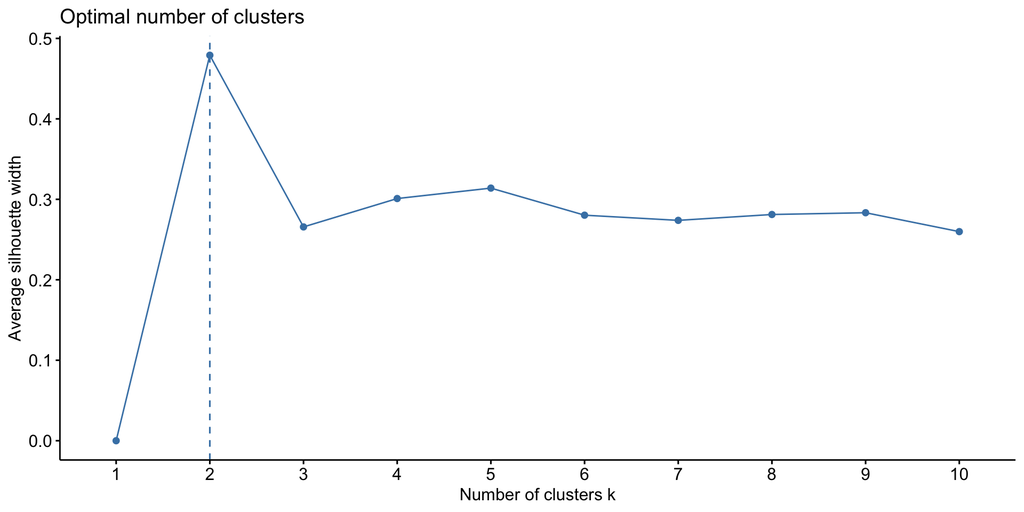

```r
df_oa <- performance_data_nav %>%
  filter(group == "OA")
df_oa <- set_subject_rownames(df_oa)

df_oa_imputed <- missForest(df_oa)$ximp
df_oa_norm <- df_oa_imputed %>%
  mutate(across(everything(), ~ (.-mean(., na.rm = TRUE)) / sd(., na.rm = TRUE)))

# Optimal number
fviz_nbclust(df_oa_imputed, hcut, method = "silhouette")
```

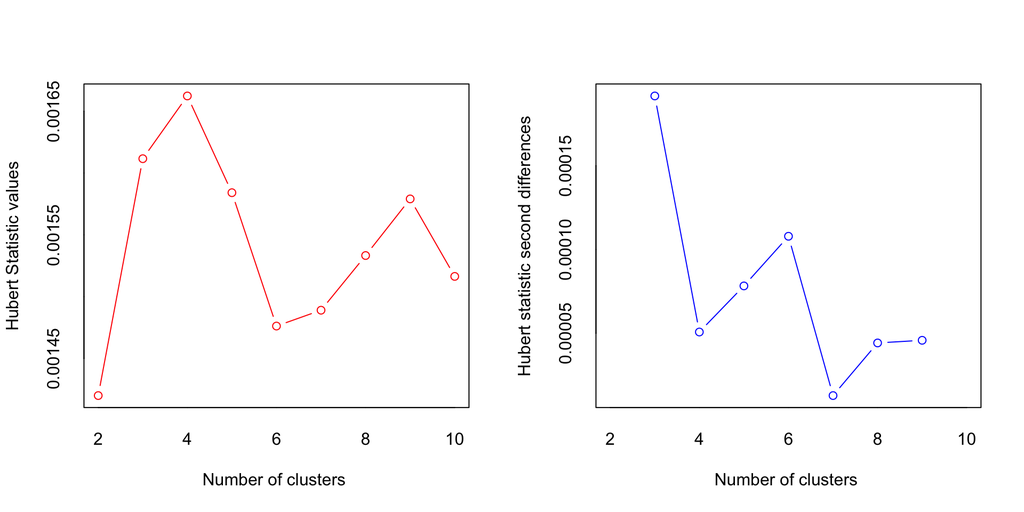

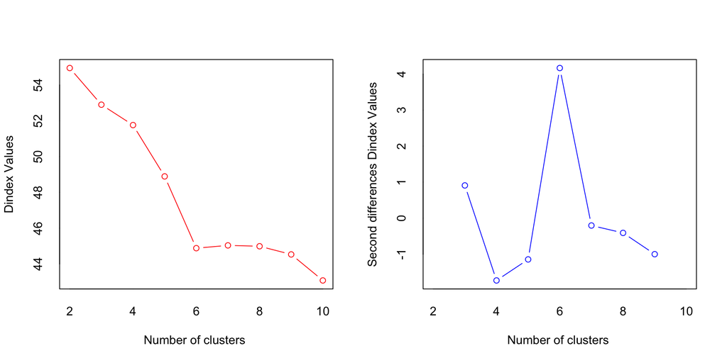

```r
# Prepare a dissimilarity matrix for NbClust
rf <- randomForest(x = df_oa_imputed, y = NULL, ntree = 20000, proximity = TRUE, oob.prox = TRUE)
d <- as.dist(1 - rf$proximity)

# Capture all output from NbClust
output <- capture.output({
  res_nbclust <- NbClust(df_oa_imputed,
                         diss=d,
                         distance = NULL,
                         min.nc = 2, max.nc = 10,
                         method = "ward.D2", index = "all")
})
```

```r
# Filter lines that match a pattern
allowed_lines <- grep("the best number of clusters", output, value = TRUE)

# Print only those lines
cat(paste(allowed_lines, collapse = "\n"), "\n")
```

```
* 9 proposed 2 as the best number of clusters
* 2 proposed 3 as the best number of clusters
* 1 proposed 4 as the best number of clusters
* 1 proposed 5 as the best number of clusters
* 5 proposed 6 as the best number of clusters
* 1 proposed 7 as the best number of clusters
* 1 proposed 8 as the best number of clusters
* 1 proposed 9 as the best number of clusters
* 2 proposed 10 as the best number of clusters
* According to the majority rule, the best number of clusters is  2
```

# Run clustering - OA

Now we run the clustering with the optimal amount of clusters.

We will see the clusters visualized with MDS and dendrogram.

Also which variables contribute to separating the clusters.

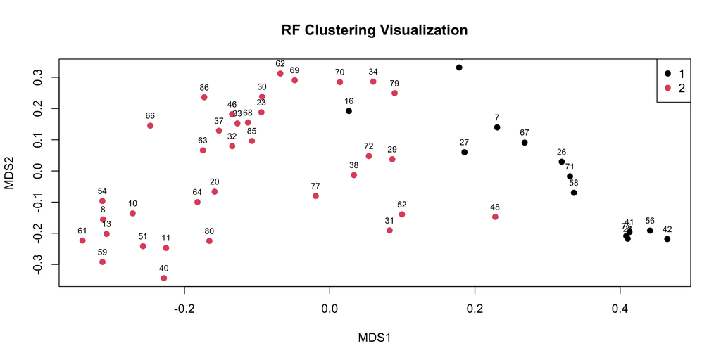

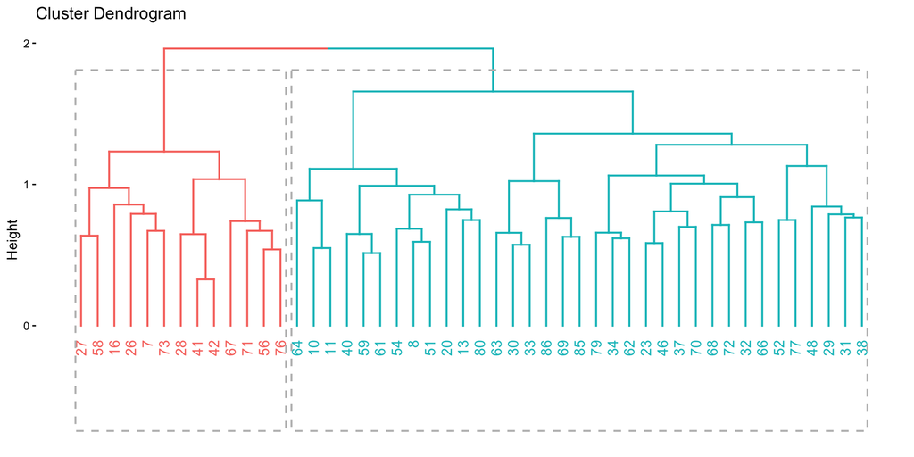

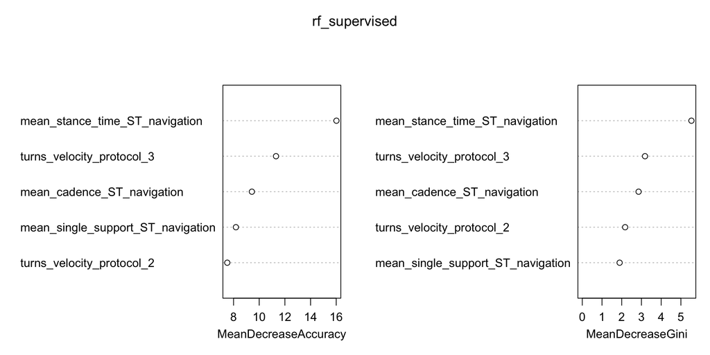

```r
# For reproducible cluster despite other changes in pipeline
set.seed(123)

# Get clusters
res_cluster_oa <- run_clustering_rf(df_oa_imputed, 2)
```

```r
cluster_rf_oa <- res_cluster_oa$cluster
```

Let’s also visualize the clusters in terms of principal components in the dataset.

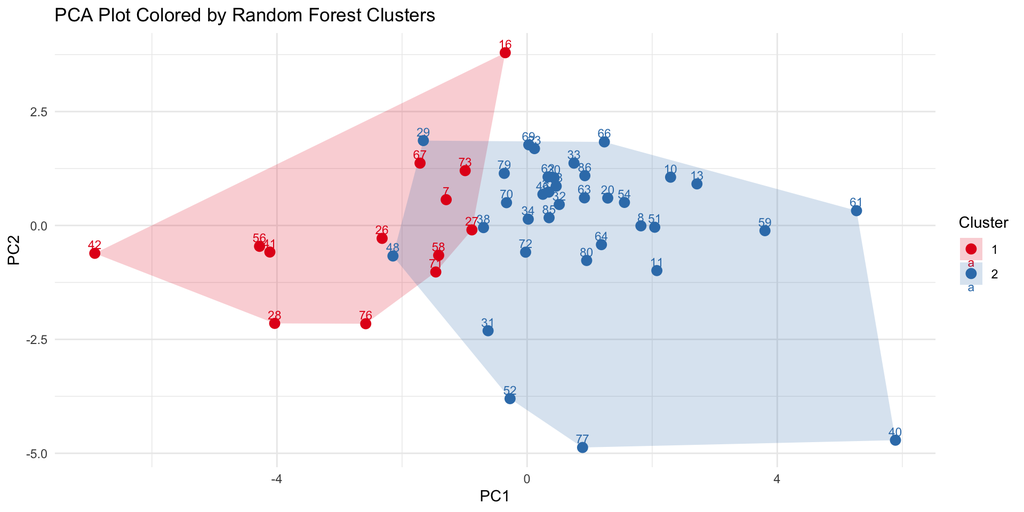

```r
# PCA for visualizing
pcs <- prcomp(df_oa_norm, center = FALSE, scale. = FALSE)$x %>% as.data.frame()
pcs$Cluster <- factor(cluster_rf_oa)
pcs$Subject <- rownames(df_oa_norm)

# Compute convex hulls for each cluster
hulls <- pcs %>%
  group_by(Cluster) %>%
  slice(chull(PC1, PC2))

# Plot the first two principal components
ggplot(pcs, aes(x = PC1, y = PC2, color = Cluster, label = Subject)) +
  geom_polygon(data = hulls, aes(fill = Cluster), alpha = 0.2, color = NA) +
  geom_point(size = 3) +
  geom_text(vjust = -0.5, hjust = 0.5, size = 3) +
  labs(title = "PCA Plot Colored by Random Forest Clusters",
       x = "PC1", y = "PC2") +
  theme_minimal() +
  scale_color_brewer(palette = "Set1") +
  scale_fill_brewer(palette = "Set1")
```

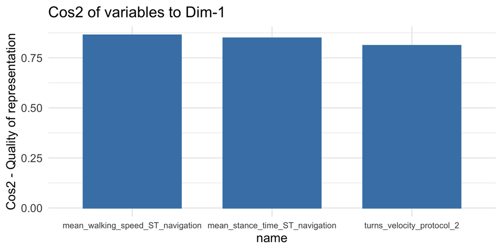

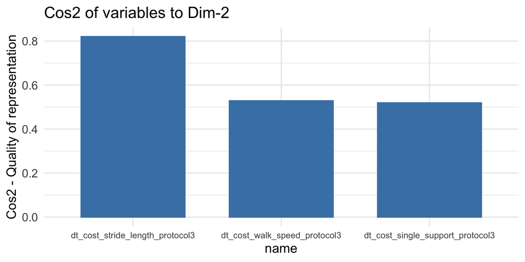

```r
check_pcs(df_oa_norm)
```

# Number of clusters - PD

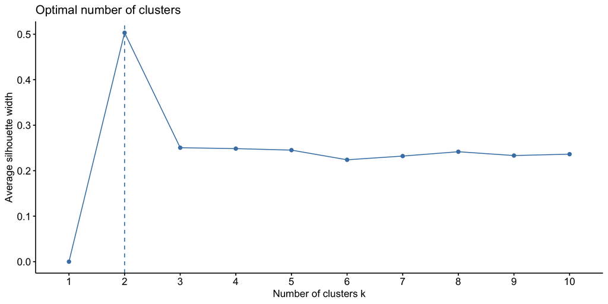

```r
df_pd <- performance_data_nav %>%
  filter(group == "PD")
df_pd <- set_subject_rownames(df_pd)

df_pd_imputed <- missForest(df_pd)$ximp
df_pd_norm <- df_pd_imputed %>%
  mutate(across(everything(), ~ (.-mean(., na.rm = TRUE)) / sd(., na.rm = TRUE)))

# Optimal number
fviz_nbclust(df_pd_imputed, hcut, method = "silhouette")
```

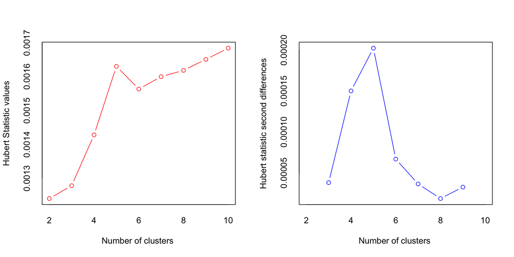

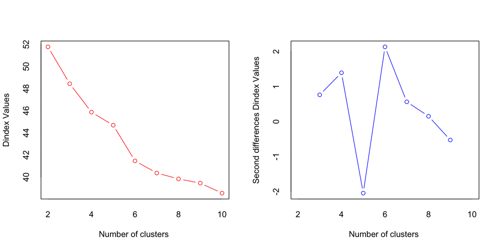

```r
# Prepare a dissimilarity matrix for NbClust
rf <- randomForest(x = df_pd_imputed, y = NULL, ntree = 20000, proximity = TRUE, oob.prox = TRUE)
d <- as.dist(1 - rf$proximity)

# Capture all output from NbClust
output <- capture.output({
  res_nbclust <- NbClust(df_pd_imputed,
                         diss = d,
                         distance = NULL,
                         min.nc = 2, max.nc = 10,
                         method = "ward.D2", index = "all")
})
```

```r
# Filter lines that match a pattern
allowed_lines <- grep("the best number of clusters", output, value = TRUE)

# Print only those lines
cat(paste(allowed_lines, collapse = "\n"), "\n")
```

```
* 7 proposed 2 as the best number of clusters
* 1 proposed 3 as the best number of clusters
* 2 proposed 4 as the best number of clusters
* 2 proposed 5 as the best number of clusters
* 5 proposed 6 as the best number of clusters
* 1 proposed 7 as the best number of clusters
* 2 proposed 8 as the best number of clusters
* 1 proposed 9 as the best number of clusters
* 2 proposed 10 as the best number of clusters
* According to the majority rule, the best number of clusters is  2
```

# Run clustering - PD

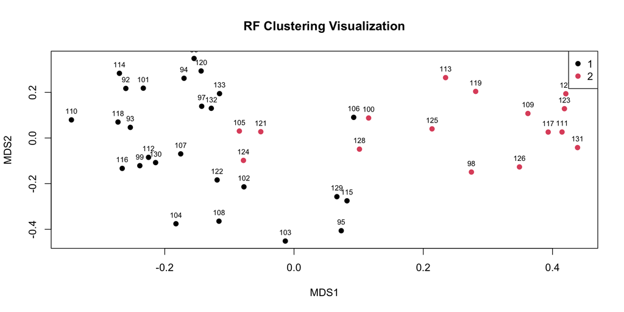

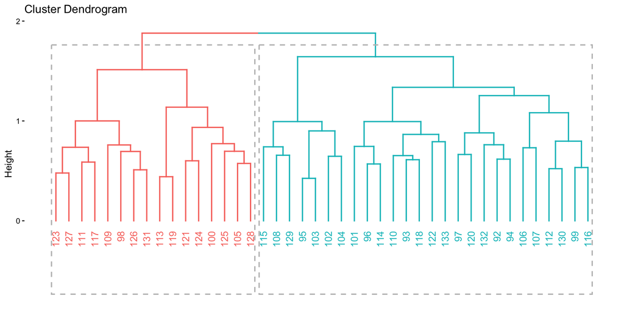

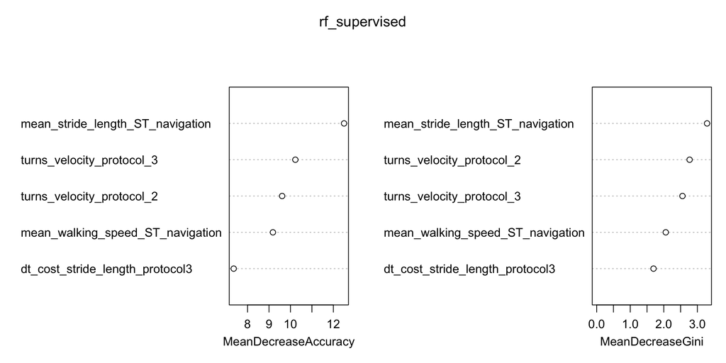

```r
# For reproducible cluster despite other changes in pipeline
set.seed(123)

# Get clusters
res_cluster_pd <- run_clustering_rf(df_pd_imputed, 2)
```

```r
cluster_rf_pd <- res_cluster_pd$cluster
```

Visualize the clusters

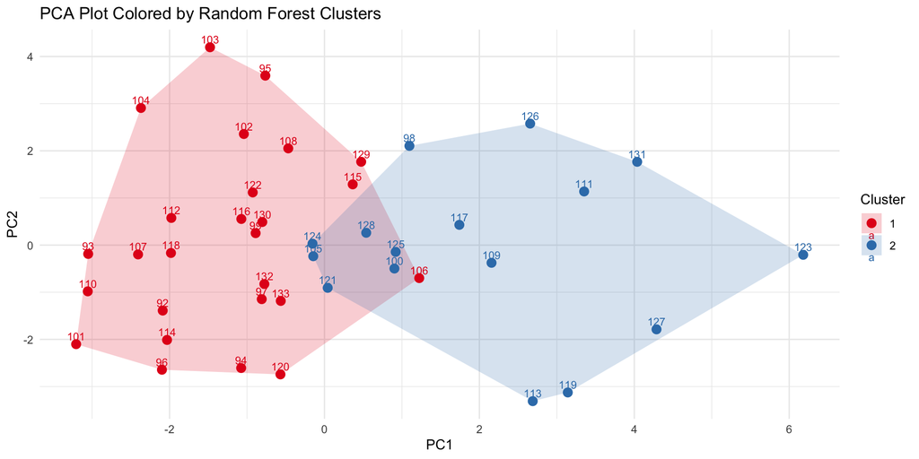

```r
# PCA for visualizing
pcs <- prcomp(df_pd_norm, center = FALSE, scale. = FALSE)$x %>% as.data.frame()
pcs$Cluster <- factor(cluster_rf_pd)
pcs$Subject <- rownames(df_pd_norm)

# Compute convex hulls for each cluster
hulls <- pcs %>%
  group_by(Cluster) %>%
  slice(chull(PC1, PC2))

# Plot the first two principal components
ggplot(pcs, aes(x = PC1, y = PC2, color = Cluster, label = Subject)) +
  geom_polygon(data = hulls, aes(fill = Cluster), alpha = 0.2, color = NA) +
  geom_point(size = 3) +
  geom_text(vjust = -0.5, hjust = 0.5, size = 3) +
  labs(title = "PCA Plot Colored by Random Forest Clusters",
       x = "PC1", y = "PC2") +
  theme_minimal() +
  scale_color_brewer(palette = "Set1") +
  scale_fill_brewer(palette = "Set1")
```

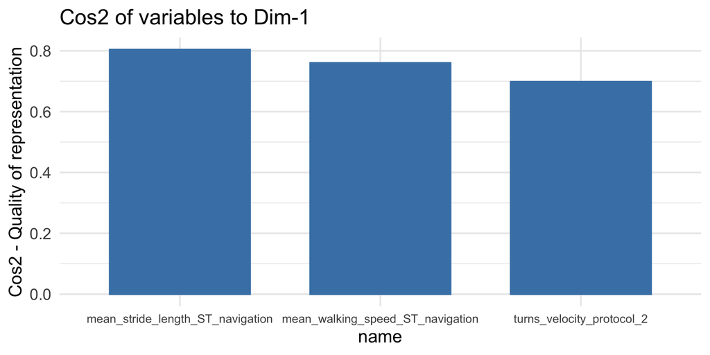

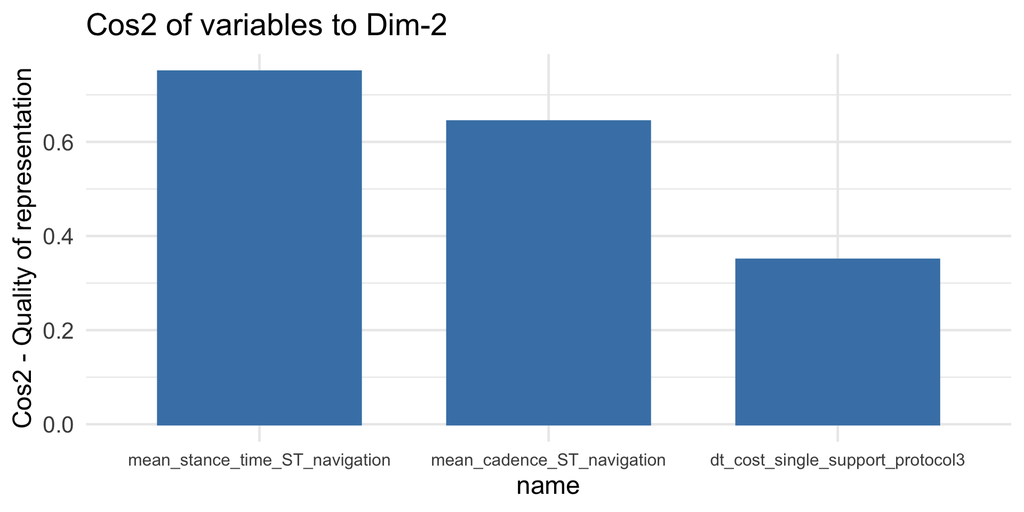

```r
check_pcs(df_pd_norm)
```

# Cluster stability

Evaluating cluster stability via Jaccard similarity values, we see that the clusters are moderately stable: one cluster in each group is valid and stable (0.76, 0.80), while one is less stable while still indicating a pattern in the data (0.61, 0.68).

From the [clusterboot documentation](https://search.r-project.org/CRAN/refmans/fpc/html/clusterboot.html):

> Generally, a valid, stable cluster should yield a mean Jaccard similarity value of 0.75 or more. Between 0.6 and 0.75, clusters may be considered as indicating patterns in the data, but which points exactly should belong to these clusters is highly doubtful. Below average Jaccard values of 0.6, clusters should not be trusted

These values are based on (Hennig 2007).

We can see that it is the larger cluster that is the more stable cluster in each group.

You can also see the moderate stability by re-running the analysis with different seeds. The core patterns are generally the same when evaluating resulting performance and demographics in the clusters but exact cluster assignment will vary somewhat.

```r
cb <- clusterboot(
  res_cluster_oa$d,
  B = 100,
  distances=TRUE,
  clustermethod = disthclustCBI,
  method = "ward.D2",
  k = 2,
  seed=123,
  showplots=FALSE,
  count=FALSE
)

print(cb, statistics = c("mean", "dissolution", "recovery"))
```

```
* Cluster stability assessment *
Cluster method:  hclust
Full clustering results are given as parameter result
of the clusterboot object, which also provides further statistics
of the resampling results.
Number of resampling runs:  100

Number of clusters found in data:  2

 Clusterwise Jaccard bootstrap (omitting multiple points) mean:
[1] 0.6081560 0.7576784
dissolved:
[1] 38 16
recovered:
[1] 26 61
```

```r
# Ensure we get the same resulting clusters
cat(
  "Which partitions do we get:\n",
  capture.output(table(cb$result$partition)),
  sep = "\n"
)
```

```
Which partitions do we get:


 1  2
13 35
```

```r
cb <- clusterboot(
  res_cluster_pd$d,
  B = 100,
  distances=TRUE,
  clustermethod = disthclustCBI,
  method = "ward.D2",
  k = 2,
  seed=123,
  showplots=FALSE,
  count=FALSE
)

print(cb, statistics = c("mean", "dissolution", "recovery"))
```

```
* Cluster stability assessment *
Cluster method:  hclust
Full clustering results are given as parameter result
of the clusterboot object, which also provides further statistics
of the resampling results.
Number of resampling runs:  100

Number of clusters found in data:  2

 Clusterwise Jaccard bootstrap (omitting multiple points) mean:
[1] 0.8022260 0.6763456
dissolved:
[1]  5 16
recovered:
[1] 71 27
```

```r
# Ensure we get the same resulting clusters
cat(
  "Which partitions do we get:\n",
  capture.output(table(cb$result$partition)),
  sep = "\n"
)
```

```
Which partitions do we get:


 1  2
26 16
```

# By actual variables - OA

We can plot the clusters in terms of actual performance variables and look at the separation.

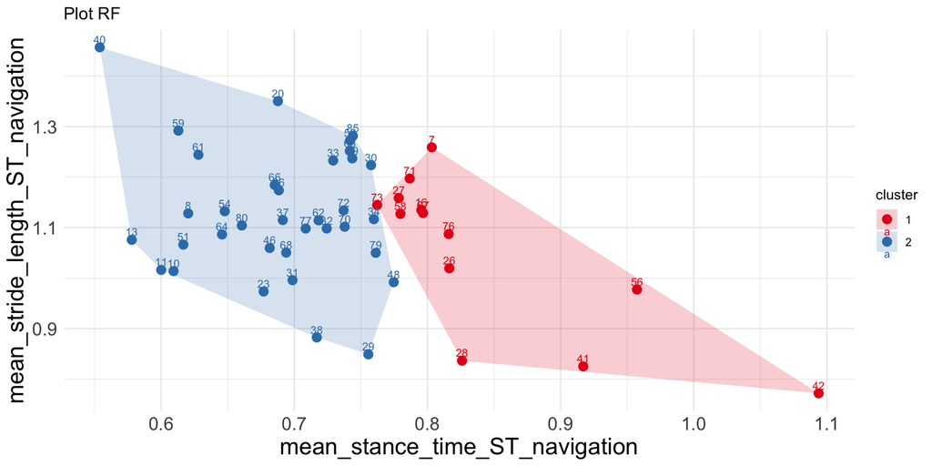

```r
plot_vars <- function(data, x_var, y_var) {
  hulls <- data %>%
    group_by(cluster) %>%
    slice(chull(.data[[x_var]], .data[[y_var]]))

  gg_point <- ggplot(data, aes(x = .data[[x_var]], y = .data[[y_var]], color = cluster)) +
    geom_polygon(data = hulls, aes(fill = cluster), alpha = 0.2, color = NA) +
    geom_point(size = 3) +
    geom_text(aes(label = subject), vjust = -0.5, size = 3) +
    labs(x = x_var, y = y_var, title = "Plot RF") +
    theme_minimal() +
    scale_color_brewer(palette = "Set1") +
    scale_fill_brewer(palette = "Set1") +
    theme(
      axis.title.x = element_text(size = 18),   # ⬅ bigger x label
      axis.title.y = element_text(size = 18),   # ⬅ bigger y label
      axis.text.x  = element_text(size = 14),   # optional: bigger tick labels
      axis.text.y  = element_text(size = 14)    # optional
    )


  print(gg_point)
}


performance_data_oa <- df_oa_imputed
performance_data_oa$subject <- rownames(performance_data_oa)
performance_data_oa$cluster <- as.factor(cluster_rf_oa)

plot_vars(performance_data_oa, "mean_stance_time_ST_navigation", "mean_stride_length_ST_navigation")
```

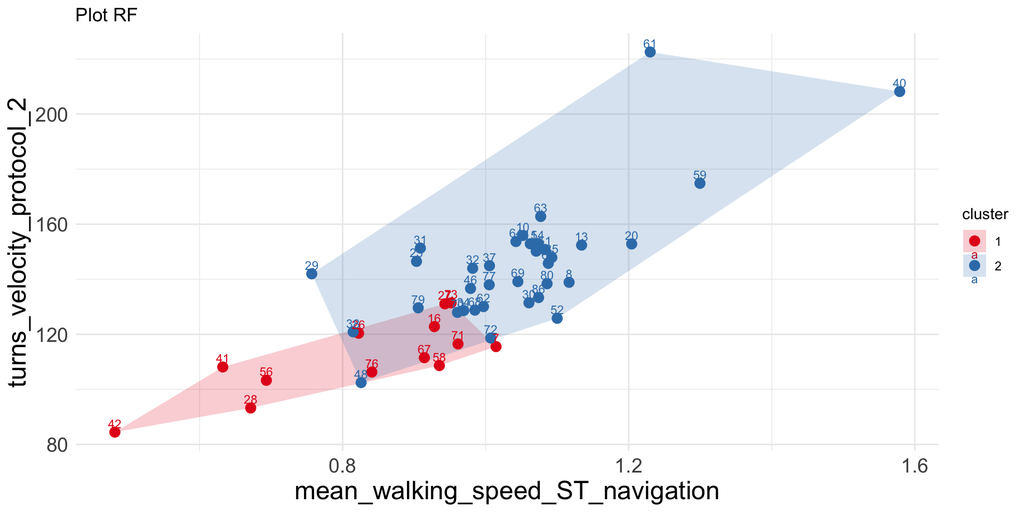

```r
plot_vars(performance_data_oa, "mean_walking_speed_ST_navigation", "turns_velocity_protocol_2")
```

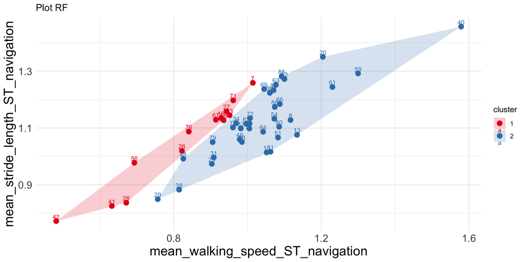

```r
plot_vars(performance_data_oa, "mean_walking_speed_ST_navigation", "mean_stride_length_ST_navigation")
```

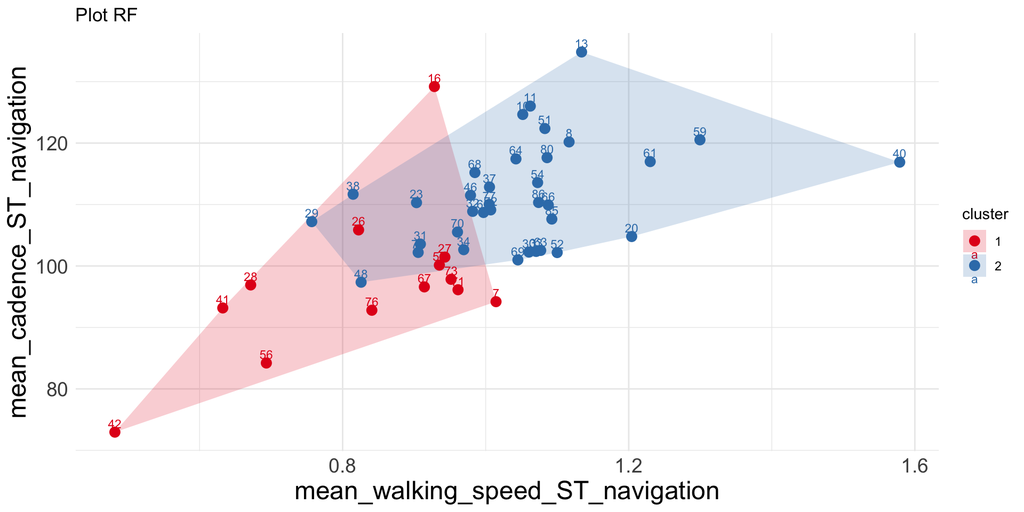

```r
plot_vars(performance_data_oa, "mean_walking_speed_ST_navigation", "mean_cadence_ST_navigation")
```

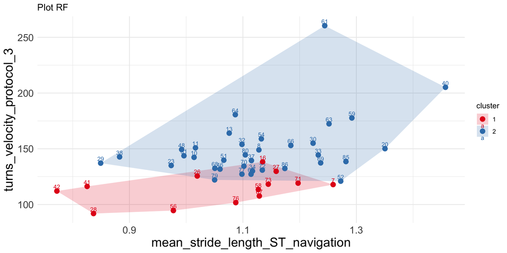

```r
plot_vars(performance_data_oa, "mean_stride_length_ST_navigation", "turns_velocity_protocol_3")
```

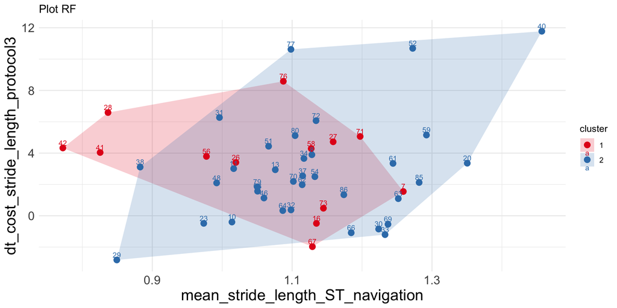

```r
plot_vars(performance_data_oa, "mean_stride_length_ST_navigation", "dt_cost_stride_length_protocol3")
```

# By actual variables - PD

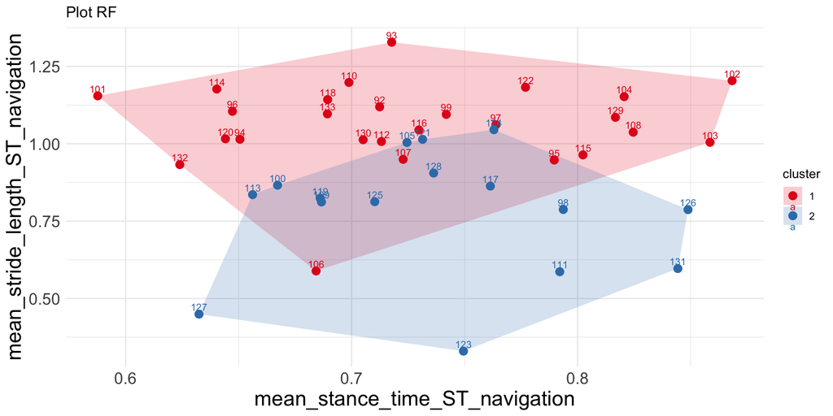

```r
performance_data_pd <- df_pd_imputed
performance_data_pd$subject <- rownames(performance_data_pd)
performance_data_pd$cluster <- as.factor(cluster_rf_pd)

plot_vars(performance_data_pd, "mean_stance_time_ST_navigation", "mean_stride_length_ST_navigation")
```

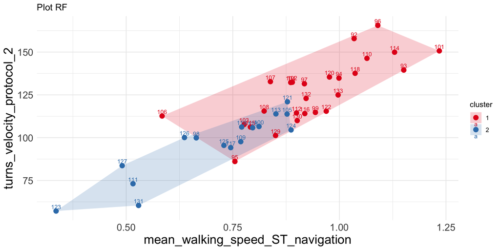

```r
plot_vars(performance_data_pd, "mean_walking_speed_ST_navigation", "turns_velocity_protocol_2")
```

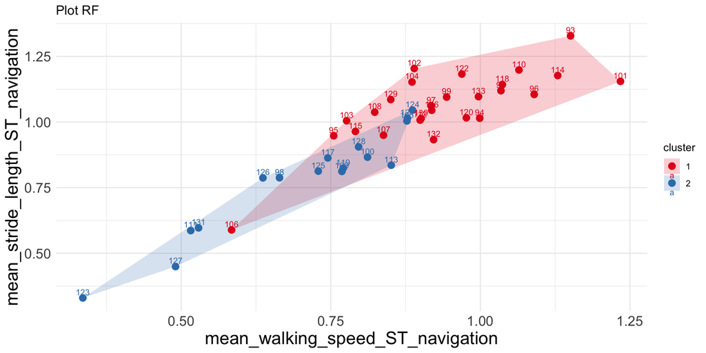

```r
plot_vars(performance_data_pd, "mean_walking_speed_ST_navigation", "mean_stride_length_ST_navigation")
```

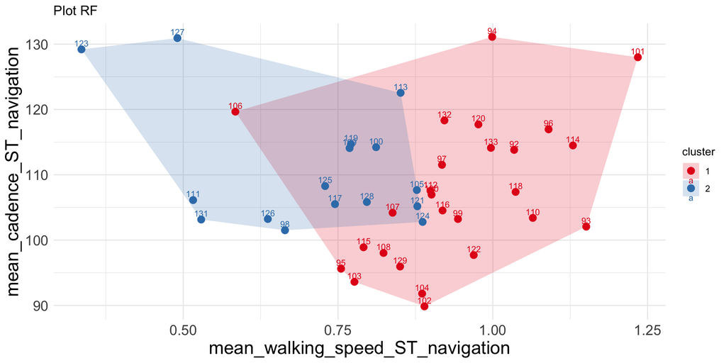

```r
plot_vars(performance_data_pd, "mean_walking_speed_ST_navigation", "mean_cadence_ST_navigation")
```

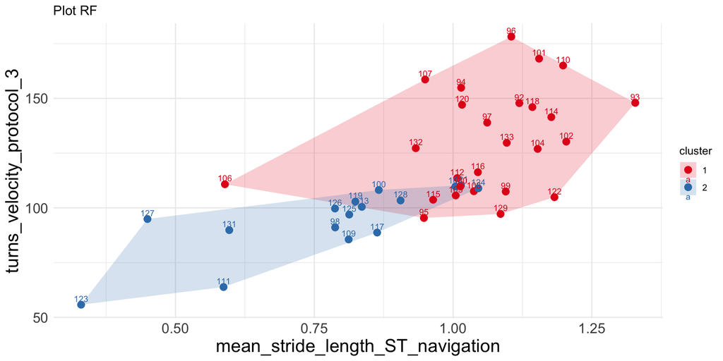

```r
plot_vars(performance_data_pd, "mean_stride_length_ST_navigation", "turns_velocity_protocol_3")
```

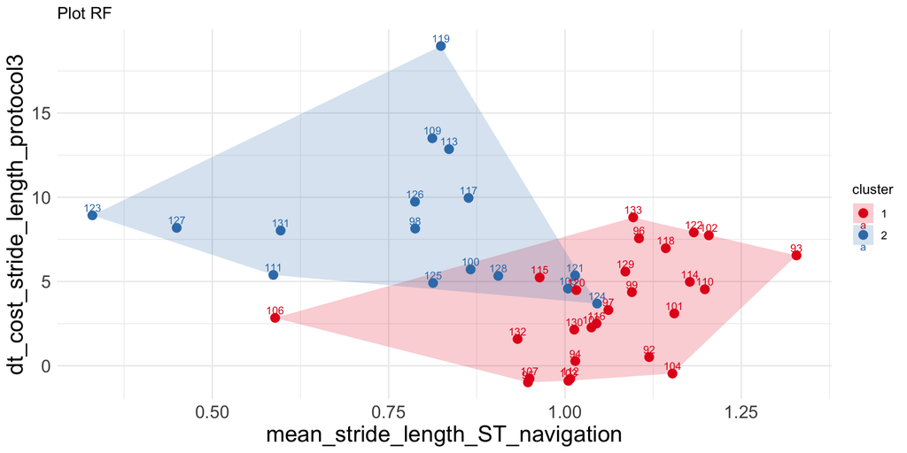

```r
plot_vars(performance_data_pd, "mean_stride_length_ST_navigation", "dt_cost_stride_length_protocol3")
```

# Demographics and gait variables - OA

This is using the [*tableby*](https://cran.r-project.org/web/packages/arsenal/vignettes/tableby.html) function, with test=KWT.

```r
# Place subject code back into subject column
performance_data_nav$subject <- subject_map[as.character(performance_data_nav$subject)]
performance_data_pd$subject <- subject_map[as.character(performance_data_pd$subject)]
performance_data_oa$subject <- subject_map[as.character(performance_data_oa$subject)]

group_str = "OA"
subj_cluster <- performance_data_oa[c("subject", "cluster")]
write.csv(subj_cluster,"../data/clusters_oa.csv", row.names = FALSE)

subject_data_group <- subject_data %>%
  filter(group == group_str)
performance_data_group <- performance_data %>%
  filter(group == group_str)

subject_data_cluster <- merge(subject_data_group, subj_cluster, by = "subject", all = TRUE)
performance_data_cluster <- merge(performance_data_group, subj_cluster, by = "subject", all = TRUE)

subject_data_cluster <- copy_labels(subject_data, subject_data_cluster)
performance_data_cluster <- copy_labels(performance_data, performance_data_cluster)

# https://cran.r-project.org/web/packages/arsenal/vignettes/tableby.html

# Properties for all tables
mycontrols  <- tableby.control(numeric.test="kwt", cat.test="chisq",  cat.simplify = TRUE, cat.stats="countpct",
                               numeric.simplify=TRUE, numeric.stats=c("meansd"),
                               digits=2, digits.p=2, digits.pct=1)

# Create tables
tab1 <- tableby(cluster ~ sex + age + crf_utbildning_ar + weight + height + frandin_grimby.x + ramlat_12_man,
                data=subject_data_cluster, control=mycontrols)

tab2 <- tableby(cluster ~ mb_total + g12_sum + tmt_2 + tmt_4 + tmt_4_tmt_2_contrast + cwit_3 + ravlt_ret,
                data=subject_data_cluster, control=mycontrols)

tab3 <- tableby(cluster ~
                mean_walking_speed_protocol1_ST_walk +
                mean_walking_speed_protocol1_DT_walk +
                mean_stride_length_protocol1_ST_walk +
                mean_stride_length_protocol1_DT_walk +
                mean_step_time_protocol1_ST_walk +
                mean_step_time_protocol1_DT_walk +
                step_time_variability_protocol1_ST_walk +
                step_time_variability_protocol1_DT_walk +
                dt_cost_walk_speed_protocol1 +
                dt_cost_stride_length_protocol1,
                data=performance_data_cluster, control=mycontrols)

tab4 <- tableby(cluster ~
                mean_walking_speed_protocol2_ST_walk +
                mean_walking_speed_protocol2_ST_navigation +
                mean_stride_length_protocol2_ST_walk +
                mean_stride_length_protocol2_ST_navigation +
                mean_step_time_protocol2_ST_walk +
                mean_step_time_protocol2_ST_navigation +
                step_time_variability_protocol2_ST_walk +
                step_time_variability_protocol2_ST_navigation +
                turns_velocity_protocol_2 +
                nav_s2_hesitation +
                nav_s2_wrong,
                data=performance_data_cluster, control=mycontrols)

tab5 <- tableby(cluster ~
                mean_walking_speed_protocol3_ST_navigation +
                mean_walking_speed_protocol3_DT_navigation +
                mean_stride_length_protocol3_ST_navigation +
                mean_stride_length_protocol3_DT_navigation +
                mean_step_time_protocol3_ST_navigation +
                mean_step_time_protocol3_DT_navigation +
                step_time_variability_protocol3_ST_navigation +
                step_time_variability_protocol3_DT_navigation +
                dt_cost_walk_speed_protocol3 +
                dt_cost_stride_length_protocol3 +
                dt_cost_step_time_variability_protocol3 +
                turns_velocity_protocol_3 +
                acc_s3_hesitation_tot +
                acc_s3_wrong_tot,
                data=performance_data_cluster, control=mycontrols)

tab6 <- tableby(cluster ~ DT_protocol_3_stroop_acc + DT_protocol_3_stroop_time,
                data=performance_data_cluster, control=mycontrols)
```

```r
summary(tab1, title = "demographics")
```

demographics

|  | 1 (N=13) | 2 (N=35) | Total (N=48) | p value |
| --- | --- | --- | --- | --- |
| **Gender, female** | 4 (30.8%) | 17 (48.6%) | 21 (43.8%) | 0.27 |
| **Age, yrs** | 72.38 (8.72) | 68.20 (5.60) | 69.33 (6.76) | 0.14 |
| **Education, yrs** | 13.85 (3.04) | 15.50 (2.27) | 15.05 (2.57) | 0.07 |
| **Weight, kg** | 78.46 (10.87) | 72.43 (14.55) | 74.06 (13.81) | 0.21 |
| **Height, cm** | 177.08 (8.03) | 172.03 (10.52) | 173.40 (10.08) | 0.15 |
| **Frändin-Grimby** | 3.38 (1.19) | 4.23 (0.84) | 4.00 (1.01) | 0.02 |
| **Falls in last 12 months, yes** | 4 (30.8%) | 3 (8.6%) | 7 (14.6%) | 0.05 |

```r
summary(tab2, title = "clinical & neuropsychological")
```

clinical & neuropsychological

|  | 1 (N=13) | 2 (N=35) | Total (N=48) | p value |
| --- | --- | --- | --- | --- |
| **Mini-BESTest score** | 24.00 (3.07) | 25.69 (2.35) | 25.23 (2.64) | 0.06 |
| **Walk-12 sum** | 1.78 (1.86) | 1.55 (2.38) | 1.61 (2.25) | 0.21 |
| **TMT2, s** | 43.28 (24.63) | 34.34 (11.52) | 36.76 (16.34) | 0.52 |
| **TMT4, s** | 91.15 (42.19) | 75.60 (27.03) | 79.57 (31.82) | 0.38 |
| **TMT4 - TMT2, s** | 51.30 (35.05) | 41.27 (28.85) | 43.83 (30.47) | 0.56 |
| **CWIT3, s** | 67.95 (24.03) | 58.80 (14.80) | 61.28 (17.97) | 0.22 |
| **RAVLT retention, words** | 10.23 (4.30) | 11.03 (2.86) | 10.81 (3.29) | 0.80 |

```r
summary(tab3, title = "Gait variables, protocol 1")
```

Gait variables, protocol 1

|  | 1 (N=13) | 2 (N=35) | Total (N=48) | p value |
| --- | --- | --- | --- | --- |
| **Walking speed (ST), m/s** | 1.07 (0.23) | 1.31 (0.18) | 1.24 (0.22) | < 0.01 |
| **Walking speed (DT), m/s** | 1.06 (0.25) | 1.30 (0.18) | 1.23 (0.23) | < 0.01 |
| **Stride length (ST), m** | 1.30 (0.21) | 1.39 (0.14) | 1.36 (0.17) | 0.18 |
| **Stride length (DT), m** | 1.29 (0.22) | 1.37 (0.15) | 1.35 (0.18) | 0.35 |
| **Step time (ST), s** | 0.62 (0.07) | 0.53 (0.05) | 0.56 (0.07) | < 0.01 |
| **Step time (DT), s** | 0.62 (0.07) | 0.53 (0.05) | 0.56 (0.07) | < 0.01 |
| **Step time variability (ST), ms** | 20.23 (5.20) | 17.35 (7.30) | 18.18 (6.83) | 0.03 |
| **Step time variability (DT), ms** | 22.24 (12.22) | 16.95 (15.59) | 18.48 (14.76) | 0.05 |
| **DT cost walking speed, %** | 1.12 (4.34) | 0.83 (4.12) | 0.92 (4.13) | 0.41 |
| **DT cost stride length, %** | 1.03 (2.64) | 1.08 (2.56) | 1.07 (2.55) | 0.96 |

```r
summary(tab4, title = "Gait variables, protocol 2")
```

Gait variables, protocol 2

|  | 1 (N=13) | 2 (N=35) | Total (N=48) | p value |
| --- | --- | --- | --- | --- |
| **Walking speed (straight), m/s** | 1.07 (0.23) | 1.30 (0.15) | 1.23 (0.20) | < 0.01 |
| **Walking speed (navigation), m/s** | 0.81 (0.16) | 1.03 (0.15) | 0.97 (0.18) | < 0.01 |
| **Stride length (straight), m** | 1.29 (0.22) | 1.37 (0.13) | 1.35 (0.16) | 0.34 |
| **Stride length (navigation), m** | 1.04 (0.15) | 1.12 (0.14) | 1.10 (0.14) | 0.25 |
| **Step time (straight), s** | 0.61 (0.06) | 0.53 (0.05) | 0.55 (0.06) | < 0.01 |
| **Step time (navigation), s** | 0.66 (0.06) | 0.56 (0.04) | 0.59 (0.07) | < 0.01 |
| **Step time variability (straight), ms** | 21.66 (9.31) | 15.34 (5.62) | 16.99 (7.23) | 0.01 |
| **Step time variability (navigation), ms** | 57.79 (17.68) | 46.94 (18.21) | 49.94 (18.53) | 0.10 |
| **Turn velocity (peak), deg/s** | 111.34 (14.54) | 145.18 (22.40) | 137.09 (25.28) | < 0.01 |
| **Hesitations (navigation)** | 1.25 (1.60) | 2.24 (3.49) | 1.98 (3.12) | 0.45 |
| **Mistakes (navigation)** | 2.75 (5.15) | 2.41 (4.59) | 2.50 (4.69) | 0.71 |

```r
summary(tab5, title = "Gait variables, protocol 3")
```

Gait variables, protocol 3

|  | 1 (N=13) | 2 (N=35) | Total (N=48) | p value |
| --- | --- | --- | --- | --- |
| **Walking speed (ST), m/s** | 0.88 (0.14) | 1.06 (0.15) | 1.01 (0.16) | < 0.01 |
| **Walking speed (DT), m/s** | 0.85 (0.14) | 1.04 (0.12) | 0.99 (0.15) | < 0.01 |
| **Stride length (ST), m** | 1.08 (0.14) | 1.13 (0.13) | 1.12 (0.13) | 0.35 |
| **Stride length (DT), m** | 1.05 (0.15) | 1.10 (0.12) | 1.09 (0.13) | 0.49 |
| **Step time (ST), s** | 0.62 (0.03) | 0.54 (0.04) | 0.56 (0.05) | < 0.01 |
| **Step time (DT), s** | 0.62 (0.04) | 0.54 (0.04) | 0.56 (0.05) | < 0.01 |
| **Step time variability (ST), ms** | 54.55 (26.93) | 44.85 (24.25) | 47.38 (25.04) | 0.31 |
| **Step time variability (DT), ms** | 53.69 (21.51) | 47.94 (28.81) | 49.44 (26.99) | 0.22 |
| **DT cost walking speed, %** | 2.72 (3.83) | 1.98 (4.38) | 2.17 (4.22) | 0.39 |
| **DT cost stride length, %** | 3.34 (3.00) | 2.78 (3.32) | 2.92 (3.22) | 0.31 |
| **DT cost step time variability, %** | 14.33 (48.16) | 17.18 (57.82) | 16.43 (54.96) | 0.80 |
| **Turn velocity (peak), deg/s** | 113.25 (14.71) | 149.41 (26.55) | 141.19 (28.66) | < 0.01 |
| **Hesitations (total)** | 1.83 (2.21) | 2.39 (3.92) | 2.24 (3.53) | 0.95 |
| **Mistakes (total)** | 0.17 (0.39) | 0.66 (1.07) | 0.52 (0.95) | 0.21 |

```r
summary(tab6, title = "Auditory Stroop, protocol 3")
```

Auditory Stroop, protocol 3

|  | 1 (N=13) | 2 (N=35) | Total (N=48) | p value |
| --- | --- | --- | --- | --- |
| **Accuracy (DT), %** | 98.41 (2.34) | 96.01 (9.91) | 96.64 (8.63) | 0.84 |
| **Answer time (DT), s** | 1.27 (0.27) | 1.13 (0.17) | 1.16 (0.21) | 0.14 |

# Demographics and gait variables - PD

```r
group_str = "PD"
subj_cluster <- performance_data_pd[c("subject", "cluster")]
write.csv(subj_cluster,"../data/clusters_pd.csv", row.names = FALSE)

subject_data_group <- subject_data %>%
  filter(group == group_str)
performance_data_group <- performance_data %>%
  filter(group == group_str)

subject_data_cluster <- merge(subject_data_group, subj_cluster, by = "subject", all = TRUE)
performance_data_cluster <- merge(performance_data_group, subj_cluster, by = "subject", all = TRUE)

subject_data_cluster <- copy_labels(subject_data, subject_data_cluster)
performance_data_cluster <- copy_labels(performance_data, performance_data_cluster)

# https://cran.r-project.org/web/packages/arsenal/vignettes/tableby.html

# Properties for all tables
mycontrols  <- tableby.control(numeric.test="kwt", cat.test="chisq",  cat.simplify = TRUE, cat.stats="countpct",
                               numeric.simplify=TRUE, numeric.stats=c("meansd"),
                               digits=2, digits.p=2, digits.pct=1)

# No good function for creating sub-headings in the table
# But we could create separate tables for display for now (and then all together for correct statistics later)
tab1 <- tableby(cluster ~ sex + age + crf_utbildning_ar + weight + height + frandin_grimby.x + ramlat_12_man,
                data=subject_data_cluster, control=mycontrols)


tab2 <- tableby(cluster ~ mb_total + g12_sum + tmt_2 + tmt_4 + tmt_4_tmt_2_contrast + cwit_3 + ravlt_ret,
                data=subject_data_cluster, control=mycontrols)



tab3 <- tableby(cluster ~
                mean_walking_speed_protocol1_ST_walk +
                mean_walking_speed_protocol1_DT_walk +
                mean_stride_length_protocol1_ST_walk +
                mean_stride_length_protocol1_DT_walk +
                mean_step_time_protocol1_ST_walk +
                mean_step_time_protocol1_DT_walk +
                step_time_variability_protocol1_ST_walk +
                step_time_variability_protocol1_DT_walk +
                dt_cost_walk_speed_protocol1 +
                dt_cost_stride_length_protocol1,
                data=performance_data_cluster, control=mycontrols)

tab4 <- tableby(cluster ~
                mean_walking_speed_protocol2_ST_walk +
                mean_walking_speed_protocol2_ST_navigation +
                mean_stride_length_protocol2_ST_walk +
                mean_stride_length_protocol2_ST_navigation +
                mean_step_time_protocol2_ST_walk +
                mean_step_time_protocol2_ST_navigation +
                step_time_variability_protocol2_ST_walk +
                step_time_variability_protocol2_ST_navigation +
                turns_velocity_protocol_2 +
                nav_s2_hesitation +
                nav_s2_wrong,
                data=performance_data_cluster, control=mycontrols)


tab5 <- tableby(cluster ~
                mean_walking_speed_protocol3_ST_navigation +
                mean_walking_speed_protocol3_DT_navigation +
                mean_stride_length_protocol3_ST_navigation +
                mean_stride_length_protocol3_DT_navigation +
                mean_step_time_protocol3_ST_navigation +
                mean_step_time_protocol3_DT_navigation +
                step_time_variability_protocol3_ST_navigation +
                step_time_variability_protocol3_DT_navigation +
                dt_cost_walk_speed_protocol3 +
                dt_cost_stride_length_protocol3 +
                dt_cost_step_time_variability_protocol3 +
                turns_velocity_protocol_3 +
                acc_s3_hesitation_tot +
                acc_s3_wrong_tot,
                data=performance_data_cluster, control=mycontrols)


labels(performance_data_cluster)  <- c(
  DT_protocol_3_stroop_acc = "Accuracy (DT), %",
  DT_protocol_3_stroop_time = "Answer time (DT), s")

tab6 <- tableby(cluster ~ DT_protocol_3_stroop_acc + DT_protocol_3_stroop_time,
                data=performance_data_cluster, control=mycontrols)
```

```r
summary(tab1, title = "demographics")
```

demographics

|  | 1 (N=26) | 2 (N=16) | Total (N=42) | p value |
| --- | --- | --- | --- | --- |
| **Gender, female** | 13 (50.0%) | 6 (37.5%) | 19 (45.2%) | 0.43 |
| **Age, yrs** | 67.23 (6.30) | 72.75 (7.84) | 69.33 (7.35) | 0.02 |
| **Education, yrs** | 16.32 (1.76) | 14.72 (2.65) | 15.70 (2.26) | 0.02 |
| **Weight, kg** | 75.92 (19.22) | 75.56 (13.73) | 75.78 (17.10) | 0.96 |
| **Height, cm** | 173.24 (10.22) | 173.56 (8.69) | 173.37 (9.54) | 0.85 |
| **Frändin-Grimby** | 3.84 (0.80) | 3.75 (1.06) | 3.80 (0.90) | 0.65 |
| **Falls in last 12 months, yes** | 5 (20.0%) | 5 (31.2%) | 10 (24.4%) | 0.41 |

```r
summary(tab2, title = "clinical & neuropsychological")
```

clinical & neuropsychological

|  | 1 (N=26) | 2 (N=16) | Total (N=42) | p value |
| --- | --- | --- | --- | --- |
| **Mini-BESTest score** | 23.83 (3.06) | 22.07 (4.40) | 23.15 (3.68) | 0.13 |
| **Walk-12 sum** | 6.12 (4.94) | 9.62 (7.84) | 7.53 (6.41) | 0.18 |
| **TMT2, s** | 46.32 (29.53) | 73.31 (28.52) | 56.85 (31.72) | < 0.01 |
| **TMT4, s** | 87.15 (41.02) | 153.95 (89.76) | 111.13 (69.81) | < 0.01 |
| **TMT4 - TMT2, s** | 40.83 (38.21) | 83.77 (75.91) | 56.24 (57.69) | 0.03 |
| **CWIT3, s** | 57.29 (9.82) | 66.11 (12.78) | 60.73 (11.75) | 0.02 |
| **RAVLT retention, words** | 9.15 (3.06) | 8.25 (3.09) | 8.81 (3.06) | 0.39 |

```r
summary(tab3, title = "Gait variables, protocol 1")
```

Gait variables, protocol 1

|  | 1 (N=26) | 2 (N=16) | Total (N=42) | p value |
| --- | --- | --- | --- | --- |
| **Walking speed (ST), m/s** | 1.26 (0.19) | 1.08 (0.16) | 1.19 (0.20) | < 0.01 |
| **Walking speed (DT), m/s** | 1.21 (0.18) | 0.99 (0.18) | 1.13 (0.21) | < 0.01 |
| **Stride length (ST), m** | 1.36 (0.17) | 1.16 (0.16) | 1.29 (0.19) | < 0.01 |
| **Stride length (DT), m** | 1.33 (0.16) | 1.08 (0.18) | 1.24 (0.21) | < 0.01 |
| **Step time (ST), s** | 0.55 (0.04) | 0.54 (0.03) | 0.54 (0.04) | 0.53 |
| **Step time (DT), s** | 0.55 (0.04) | 0.54 (0.03) | 0.55 (0.04) | 0.44 |
| **Step time variability (ST), ms** | 17.19 (9.38) | 31.66 (22.61) | 22.62 (16.97) | 0.01 |
| **Step time variability (DT), ms** | 17.39 (6.22) | 33.10 (20.50) | 23.43 (15.43) | < 0.01 |
| **DT cost walking speed, %** | 1.69 (3.02) | 7.82 (6.40) | 4.05 (5.45) | < 0.01 |
| **DT cost stride length, %** | 1.52 (2.02) | 7.08 (6.15) | 3.66 (4.89) | < 0.01 |

```r
summary(tab4, title = "Gait variables, protocol 2")
```

Gait variables, protocol 2

|  | 1 (N=26) | 2 (N=16) | Total (N=42) | p value |
| --- | --- | --- | --- | --- |
| **Walking speed (straight), m/s** | 1.22 (0.15) | 0.96 (0.23) | 1.12 (0.22) | < 0.01 |
| **Walking speed (navigation), m/s** | 0.91 (0.14) | 0.68 (0.15) | 0.82 (0.18) | < 0.01 |
| **Stride length (straight), m** | 1.33 (0.15) | 1.05 (0.26) | 1.23 (0.24) | < 0.01 |
| **Stride length (navigation), m** | 1.04 (0.13) | 0.76 (0.19) | 0.93 (0.21) | < 0.01 |
| **Step time (straight), s** | 0.55 (0.04) | 0.54 (0.04) | 0.55 (0.04) | 0.83 |
| **Step time (navigation), s** | 0.58 (0.05) | 0.56 (0.05) | 0.57 (0.05) | 0.29 |
| **Step time variability (straight), ms** | 16.50 (6.82) | 27.15 (17.02) | 20.22 (12.36) | 0.03 |
| **Step time variability (navigation), ms** | 64.78 (27.43) | 68.38 (30.12) | 66.10 (28.12) | 0.70 |
| **Turn velocity (peak), deg/s** | 126.65 (18.77) | 94.65 (18.50) | 114.94 (24.15) | < 0.01 |
| **Hesitations (navigation)** | 2.12 (3.60) | 2.47 (3.52) | 2.25 (3.53) | 0.92 |
| **Mistakes (navigation)** | 1.84 (4.23) | 2.93 (6.03) | 2.25 (4.93) | 0.95 |

```r
summary(tab5, title = "Gait variables, protocol 3")
```

Gait variables, protocol 3

|  | 1 (N=26) | 2 (N=16) | Total (N=42) | p value |
| --- | --- | --- | --- | --- |
| **Walking speed (ST), m/s** | 0.97 (0.15) | 0.77 (0.12) | 0.91 (0.17) | < 0.01 |
| **Walking speed (DT), m/s** | 0.94 (0.13) | 0.70 (0.11) | 0.87 (0.16) | < 0.01 |
| **Stride length (ST), m** | 1.09 (0.14) | 0.86 (0.12) | 1.02 (0.17) | < 0.01 |
| **Stride length (DT), m** | 1.05 (0.13) | 0.79 (0.13) | 0.97 (0.18) | < 0.01 |
| **Step time (ST), s** | 0.57 (0.06) | 0.56 (0.04) | 0.57 (0.05) | 0.71 |
| **Step time (DT), s** | 0.56 (0.05) | 0.56 (0.03) | 0.56 (0.05) | 1.00 |
| **Step time variability (ST), ms** | 47.46 (19.85) | 60.97 (41.79) | 51.73 (28.74) | 0.22 |
| **Step time variability (DT), ms** | 58.17 (20.60) | 61.53 (44.59) | 59.23 (29.67) | 0.51 |
| **DT cost walking speed, %** | 2.24 (4.32) | 8.71 (6.03) | 4.29 (5.72) | < 0.01 |
| **DT cost stride length, %** | 3.44 (3.07) | 8.63 (4.58) | 5.08 (4.31) | < 0.01 |
| **DT cost step time variability, %** | 33.41 (51.43) | 2.11 (26.62) | 23.53 (47.06) | 0.06 |
| **Turn velocity (peak), deg/s** | 130.02 (23.91) | 93.52 (16.86) | 117.85 (27.74) | < 0.01 |
| **Hesitations (total)** | 1.81 (3.58) | 3.38 (5.28) | 2.33 (4.22) | 0.30 |
| **Mistakes (total)** | 2.15 (5.39) | 2.00 (1.54) | 2.11 (4.51) | 0.02 |

```r
summary(tab6, title = "Auditory Stroop, protocol 3")
```

Auditory Stroop, protocol 3

|  | 1 (N=26) | 2 (N=16) | Total (N=42) | p value |
| --- | --- | --- | --- | --- |
| **Accuracy (DT), %** | 96.57 (7.08) | 85.88 (14.84) | 92.74 (11.57) | < 0.01 |
| **Answer time (DT), s** | 1.19 (0.23) | 1.19 (0.14) | 1.19 (0.20) | 0.79 |

# Disease severity - PD

```r
updrs_file <- paste("../../Park-MOVE_fnirs_dataset_v2/REDcap_data/UPDRS_data.csv", sep="")
measurement_date_file <- paste("../../Park-MOVE_fnirs_dataset_v2/measurement_dates.csv", sep="")

updrs_data <- read.csv(updrs_file)
updrs_data$updrs_3_total <- rowSums(updrs_data[, 35:66], na.rm = TRUE)
updrs_data <- updrs_data[c("id_nummer", "updrs_3_total")]
names(updrs_data)[names(updrs_data) == 'id_nummer'] <- 'subject'

# Get disease duration via diagnosis date and measurement date
diagnosis_data <- subject_data_cluster[c("subject", "crf_pd_year_phone")]
measurement_dates <- read.csv(measurement_date_file, sep=";")
measurement_dates$measurement_date_t1 <- as.Date(measurement_dates$measurement_date_t1, format = "%Y-%m-%d")
measurement_dates$year <- format(measurement_dates$measurement_date_t1, "%Y")
measurement_dates <- measurement_dates[c("subject", "year")]
measurement_dates <- merge(diagnosis_data, measurement_dates, by = "subject", all = TRUE)
measurement_dates$disease_dur <- as.numeric(measurement_dates$year) - as.numeric(measurement_dates$crf_pd_year_phone)
measurement_dates <- measurement_dates[c("subject", "disease_dur")]

# Add measurment dates
subject_data_cluster <- merge(subject_data_cluster, measurement_dates, by = "subject", all = FALSE)
subject_data_cluster <- merge(subject_data_cluster, updrs_data, by = "subject", all = FALSE)

tab7 <- tableby(cluster ~ led_total + updrs_3_total + disease_dur,
                data=subject_data_cluster, control=mycontrols)
summary(tab7, title = "Disease severity")
```

Disease severity

|  | 1 (N=26) | 2 (N=16) | Total (N=42) | p value |
| --- | --- | --- | --- | --- |
| **led_total** | 412.74 (182.22) | 499.80 (260.82) | 451.15 (221.13) | 0.42 |
| **updrs_3_total** | 21.73 (10.84) | 30.44 (10.26) | 25.05 (11.34) | 0.03 |
| **disease_dur** | 4.62 (3.10) | 4.94 (2.74) | 4.75 (2.93) | 0.61 |

## References

Hennig, Christian. 2007. “Cluster-Wise Assessment of Cluster Stability.” *Computational Statistics & Data Analysis* 52 (1): 258–71. https://doi.org/10.1016/j.csda.2006.11.025.